# Incidence-Guided Treatment Assignment Designs for Spatial Cluster Randomized Trials

Comprehensive Simulation Study Report

Author

Andrew Walther

Published

September 24, 2026

# 1 Introduction

This report provides a comprehensive reference for the simulation study evaluating **8 treatment assignment designs** for Spatial Cluster Randomized Trials (CRTs) when outcome incidence is heterogeneous and spatially structured.

> *Given known historical incidence data exhibiting spatial heterogeneity, which treatment assignment strategy minimizes estimation error for the direct intervention effect $\hat{\tau}$ across a range of spatial dependence and spillover configurations?*

**Application context:** Sudden Unexpected Death (SUD) in North Carolina counties. The Poisson incidence mode uses an SUD base rate of 35 per 100,000, consistent with county-level analyses.

The study uses Maximum Likelihood Estimation via a spatial autoregressive model (MLE) as the primary estimator. The full simulation has 12,800 scenarios (five values of $\tau$); the primary $\tau = 1.0$ slice analyzed in most of this report has 2,560 scenarios. Queen contiguity is the primary neighbor structure and rook is a sensitivity analysis; **unless a result says otherwise, the tables and figures below pool rook and queen**. Three analytical questions structure the results:

- **Q1:** Which design performs best within each incidence generation mode?
- **Q2:** How do design rankings change as individual parameters vary?
- **Q3:** Which design wins for specific parameter combinations?

# 2 Study Region and Spatial Structure

The study region is a regular square lattice grid:

$$\mathcal{G} = \{s_1, s_2, \ldots, s_N\}$$

where each cluster $s_i$ is located at integer coordinates $(x_i, y_i)$ on a $G \times G$ grid, so $N = G^2$. In this study, $G = 10$ and $N = 100$.

## 2.1 Spatial Contiguity

Two contiguity definitions are considered:

- **Rook contiguity**: clusters sharing an edge (4-connected).
  $$\mathcal{N}_R(s_i) = \{s_j : |x_i - x_j| + |y_i - y_j| = 1\}$$
- **Queen contiguity**: clusters sharing an edge or vertex (8-connected).
  $$\mathcal{N}_Q(s_i) = \{s_j : \max(|x_i - x_j|, |y_i - y_j|) = 1\}$$

## 2.2 Spatial Weight Matrix

Let $\mathbf{A}$ denote the binary adjacency matrix where $A_{ij} = \mathbf{1}[s_j \in \mathcal{N}(s_i)]$. The row-standardized spatial weight matrix is:

$$W_{ij} = \frac{A_{ij}}{\sum_{k=1}^{N} A_{ik}}, \quad i \neq j; \quad W_{ii} = 0$$

This ensures $\sum_j W_{ij} = 1$ for each row, so spatial lags represent neighborhood averages. We construct $\mathbf{W}_R$ (rook) and $\mathbf{W}_Q$ (queen) weight matrices.

# 3 Outcome Data Generating Process

## 3.1 Spatial Durbin Model (SDM)

The outcome vector $\mathbf{Y} = (Y_1, \ldots, Y_N)^\top$ is generated from the Spatial Durbin Model:

$$\mathbf{Y} = (\mathbf{I}_N - \rho\mathbf{W})^{-1}\left[\tau\mathbf{Z} + \gamma \cdot \text{Spill}(\mathbf{Z}) + \beta\mathbf{X} + \boldsymbol{\varepsilon}\right]$$

where:

| Symbol | Description | Role |
| --- | --- | --- |
| $\mathbf{Y}$ | $N \times 1$ outcome vector | Response |
| $\rho$ | Spatial autocorrelation parameter | Controls global spatial dependence in $\mathbf{Y}$ |
| $\mathbf{W}$ | $N \times N$ row-standardized weight matrix | Spatial structure (rook or queen) |
| $\tau$ | Direct treatment effect | **Estimand of interest** (swept: $\{0.8, 1.0, 1.5, 2.0, 3.0\}$; primary: $1.0$) |
| $\mathbf{Z}$ | $N \times 1$ binary treatment vector | $Z_i \in \{0, 1\}$ |
| $\gamma$ | Spillover effect magnitude | Indirect effect via treated neighbors |
| $\text{Spill}(\mathbf{Z})$ | $N \times 1$ spillover term | See below |
| $\beta$ | Effect of baseline incidence on outcome | Covariate coefficient |
| $\mathbf{X}$ | $N \times 1$ baseline incidence vector | $X_i \in [0, 1]$ |
| $\boldsymbol{\varepsilon}$ | $N \times 1$ error vector | $\varepsilon_i \overset{\text{iid}}{\sim} N(0, \sigma^2)$ |

The spatial multiplier $(\mathbf{I}_N - \rho\mathbf{W})^{-1}$ induces global spatial dependence.

**Stationarity condition:** $|\rho| < 1 / \lambda_{\max}(\mathbf{W})$. For row-standardized $\mathbf{W}$, $\lambda_{\max} = 1$, so $|\rho| < 1$.

## 3.2 Spillover Construction

$$\text{Spill}_i = \frac{\sum_{j \in \mathcal{N}(i)} Z_j}{|\mathcal{N}(i)|} = (\mathbf{W}\mathbf{Z})_i$$

Two spillover types are considered:

1. **Control-only spillover**: $\text{Spill}_i^{(\text{ctrl})} = \gamma \cdot (\mathbf{W}\mathbf{Z})_i \cdot (1 - Z_i)$
2. **Bidirectional spillover**: $\text{Spill}_i^{(\text{both})} = \gamma \cdot (\mathbf{W}\mathbf{Z})_i$

# 4 Incidence Generation Modes

The baseline incidence vector $\mathbf{X}$ represents prior observed outcome rates. Three generation modes are considered, all producing values in $[0, 1]$.

## 4.1 Mode 1: Independent and Identically Distributed (iid)

$$X_i \overset{\text{iid}}{\sim} \text{Uniform}(0, 1), \quad i = 1, \ldots, N$$

No spatial structure; serves as the baseline. One config ($\rho_X$ = N/A).

## 4.2 Mode 2: Spatially Correlated (SAR Filter)

$$\mathbf{X}^* = (\mathbf{I}_N - \rho_X \mathbf{W})^{-1}\mathbf{u}, \quad \mathbf{u} \sim N(\mathbf{0}, \mathbf{I}_N)$$

$$X_i = \Phi(X_i^*)$$

where $\Phi(\cdot)$ is the standard normal CDF. Two configs: $\rho_X \in \{0.20, 0.50\}$.

## 4.3 Mode 3: Poisson Count-Based

1. Spatially correlated log-rates: $\log \boldsymbol{\lambda}^* = \mu_0 \cdot \mathbf{1} + (\mathbf{I}_N - \rho_X \mathbf{W})^{-1}\mathbf{u}$
2. Poisson counts: $C_i \sim \text{Poisson}(\lambda_i^* \cdot P_i)$ where $P_i = 100{,}000$ (so $\lambda P \approx 35$ expected deaths per cluster)
3. Observed rates: $R_i = C_i / P_i$
4. Rank-normalized: $X_i = (\text{rank}(R_i) - 0.5) / N$

Base rate $\mu_0 = \log(35/100{,}000)$ for SUD. Two configs: $\rho_X \in \{0.20, 0.50\}$.

**Critical design invariant:** Incidence is generated **once per (mode, $\rho_X$) configuration**: $K = 10$ surfaces $\mathbf{X}_1, \ldots, \mathbf{X}_{10}$, held fixed across all ($\rho$, $\gamma$, nb_type) scenarios. **Matched surfaces:** each design is drawn from surface $\mathbf{X}_k$, and the outcome and the analysis use the same $\mathbf{X}_k$.

## 4.4 Incidence Spatial Patterns

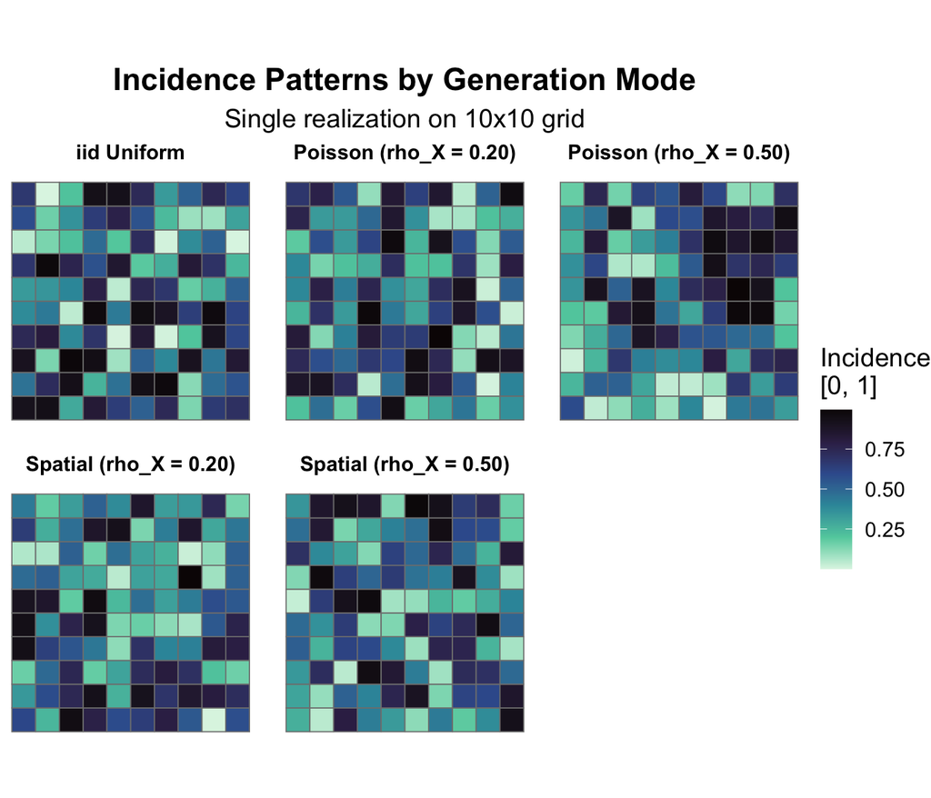

Incidence spatial patterns across generation modes. Color represents incidence (darker = higher burden). Spatial and Poisson modes show visible spatial clustering absent from iid.

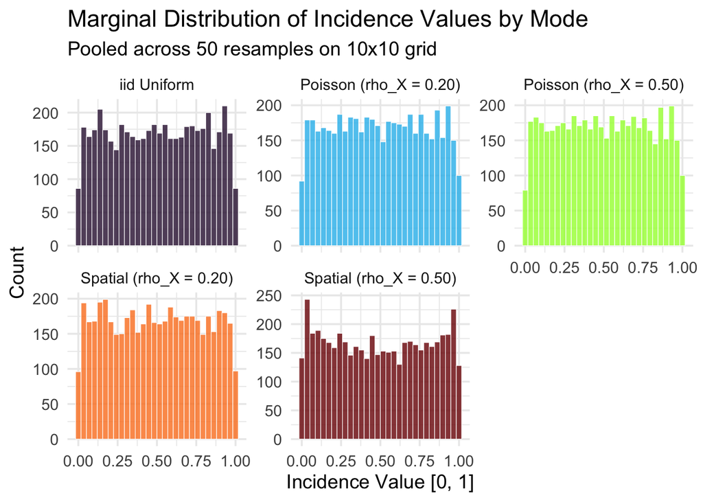

# 5 Treatment Assignment Designs

Eight designs are evaluated. Each produces a binary treatment vector $\mathbf{Z} \in \{0, 1\}^N$.

8 treatment assignment strategies evaluated in this simulation

| ID | Name | Deterministic? |
| --- | --- | --- |
| 1 | Design 1: Checkerboard | Yes |
| 2 | Design 2: High Incidence Focus | No |
| 3 | Design 3: Saturation Quadrants | No |
| 4 | Design 4: Isolation Buffer | No |
| 5 | Design 5: 2x2 Blocking | No |
| 6 | Design 6: Balanced Quartiles | No |
| 7 | Design 7: Balanced Halves | No |
| 8 | Design 8: Incidence-Guided Saturation Quadrants | No |

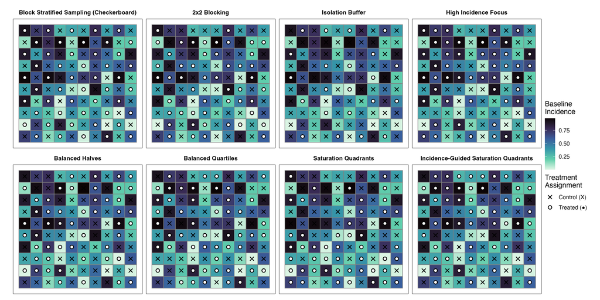

All 8 treatment assignment designs on a single 10×10 grid instance. Cell color represents baseline incidence (darker = higher burden). Circles (●) = treated clusters; crosses (×) = control clusters.

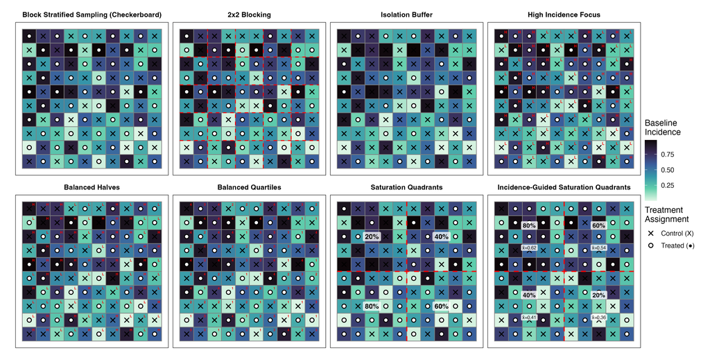

Same 8 designs with saturation percentage annotations. Percentage labels on the quadrant-based designs (Saturation Quadrants and Incidence-Guided Saturation Quadrants) show the within-quadrant treatment saturation rate assigned to each spatial region, illustrating how the two saturation quadrant strategies differ in how saturation levels are allocated.

## 5.1 Design 1: Checkerboard (Strict Spatial Stratification)

$$Z_i = (x_i + y_i) \mod 2$$

Treatment in an alternating checkerboard pattern. **Deterministic**, exactly 50% treated. It is the only deterministic design: the same assignment is used for every fit, but each fit still has its own noise draw.

## 5.2 Design 2: High Incidence Focus

$$Z_i = \mathbf{1}[r_i > N/2], \quad r = \text{rank}(\mathbf{X}_k, \text{ties broken at random})$$

Treatment assigned to the top half of clusters by incidence rank; exactly 50 treated. Ties in $\mathbf{X}_k$ are broken at random, freshly for every design draw, so the design is not deterministic.

## 5.3 Design 3: Saturation Quadrants

Grid partitioned into four spatial quadrants. Saturation levels $\{0.20, 0.40, 0.60, 0.80\}$ randomly assigned to quadrants. Within each quadrant, clusters randomly selected at the assigned rate.

## 5.4 Design 4: Isolation Buffer

Sequential treatment assignment: randomly select an available cluster, assign treatment, remove it and its neighbors from the available set. Treated clusters are never adjacent.

## 5.5 Design 5: 2x2 Blocking

Grid partitioned into non-overlapping $2 \times 2$ blocks. Within each block, exactly 2 of 4 clusters randomly assigned to treatment.

## 5.6 Design 6: Balanced Quartiles

Clusters stratified into incidence quartiles (25 each) by random-tie rank. Within each stratum 12 clusters are randomly treated, plus one more in 2 randomly chosen strata, so exactly 50 are treated.

## 5.7 Design 7: Balanced Halves

Clusters stratified into two halves (50 each) by random-tie incidence rank. Within each half, 25 clusters randomly assigned to treatment (exactly 50 treated). A 2-stratum analog of Balanced Quartiles.

## 5.8 Design 8: Incidence-Guided Saturation Quadrants

Grid partitioned into four spatial quadrants (same as Saturation Quadrants). Quadrants ranked by average baseline incidence $\bar{X}_{Q_k}$ of the design’s surface $\mathbf{X}_k$ (ties broken at random) and **deterministically** assigned saturation levels:

| Rank (by $\bar{X}_{Q_k}$) | Saturation $p_k$ |
| --- | --- |
| 1 (highest) | 0.80 |
| 2 | 0.60 |
| 3 | 0.40 |
| 4 (lowest) | 0.20 |

Within each quadrant, clusters randomly selected at the assigned rate. Unlike Saturation Quadrants, the saturation-to-quadrant mapping is guided by incidence data rather than random.

# 6 Estimation Methods

## 6.1 Difference in Means (DIM)

The naive estimator:
$$\hat{\tau}_{\text{DIM}} = \bar{Y}_1 - \bar{Y}_0$$

DIM is biased for $\tau$ when spillover ($\gamma \neq 0$) or spatial dependence ($\rho \neq 0$) is present. DIM results exist only from the pre-revision simulation (old data-generating process, 6 designs) and are not shown in this report.

## 6.2 Maximum Likelihood Estimation (MLE)

The spatial autoregressive (lag) model is estimated via maximum likelihood with the project’s lean engine `fit_sar_lag()`, which is the same estimator as `spatialreg::lagsarlm(method = "eigen")` (validated to agree to about $10^{-7}$ in $\hat{\tau}$):

$$Y_i = \rho \sum_j W_{ij} Y_j + \tau Z_i + \gamma \cdot \text{Spill}_i + \beta X_i + \varepsilon_i$$

MLE simultaneously estimates $\rho$ and regression coefficients. The true spillover covariate $\text{Spill}(\mathbf{Z})$ is included as an **oracle regressor**. Confidence intervals for $\tau$ are 95% Wald intervals from the ML standard error. A non-oracle model ($Y \sim Z + X$, no Spill term) was also fit to the same outcomes as a sensitivity analysis; its results are not shown in this report.

Under rook contiguity the Checkerboard design gives $\mathbf{W}\mathbf{Z} = \mathbf{1} - \mathbf{Z}$, so the oracle model’s Spill column is aliased with $Z$ and the intercept and is dropped: $\tau$ is not identified apart from $\gamma$. These estimates are kept but flagged (`N_Aliased`, `Z_WZ_rank_deficient`); their bias is approximately $-\gamma$.

**MLE is the primary estimator throughout this report.** DIM serves only as a naive baseline.

# 7 Simulation Design

## 7.1 Parameter Grid

Simulation parameter grid (2,560 total scenarios)

| Parameter | Values | Levels |
| --- | --- | --- |
| Incidence mode | iid, poisson, spatial | 5 configs (1 iid + 2 spatial + 2 poisson) |
| rho_X (incidence spatial autocorr.) | N/A (iid); 0.20, 0.50 (spatial, poisson) | — |
| nb_type (contiguity) | queen, rook | 2 |
| rho (outcome spatial autocorr.) | 0, 0.01, 0.2, 0.5 | 4 |
| gamma (spillover magnitude) | 0.5, 0.6, 0.7, 0.8 | 4 |
| spill_type | both, control_only | 2 |
| design_id | 1, 2, 3, 4, 5, 6, 7, 8 | 8 |
| TOTAL |  | 2,560 |

## 7.2 Resampling Structure

| Mode | Incidence surfaces ($K$) | Design draws per surface ($J$) | Fits / scenario |
| --- | --- | --- | --- |
| MLE | 10 | 25 | 250 |

For surface $k$ and design draw $j$, $\mathbf{Z}_{kj}$ is drawn from $\mathbf{X}_k$, and each of the 250 fits gets its own noise column $\boldsymbol{\varepsilon}_{kj}$: $\mathbf{Y}_{kj} = (\mathbf{I} - \rho\mathbf{W})^{-1}(\tau\mathbf{Z}_{kj} + \text{Spill}(\mathbf{Z}_{kj}) + \beta\mathbf{X}_k + \boldsymbol{\varepsilon}_{kj})$.

## 7.3 Per-Draw Reproducibility

Every random draw is preceded by `set.seed(digest::digest2int(key))`, where the key joins the fields that the draw depends on:

| Draw | Key fields |
| --- | --- |
| $\mathbf{X}_k$ (one surface) | “X”, mode, $\rho_X$, $k$ |
| $\mathbf{Z}_{k\cdot}$ (all $J$ draws for surface $k$) | “Z”, mode, $\rho_X$, nb_type, $\rho$, $\gamma$, spill_type, $k$, design |
| $\boldsymbol{\varepsilon}$ (all 250 columns for a block) | “eps”, mode, $\rho_X$, nb_type, $\rho$, $\gamma$, spill_type |

Each draw depends only on its key, so results are reproducible and order-independent. Within a block all 8 designs share $\boldsymbol{\varepsilon}$ and $\mathbf{X}_k$, and each $\tau$ reuses the same $\mathbf{Z}$ and $\boldsymbol{\varepsilon}$ (common random numbers).

# 8 Evaluation Metrics

For each scenario, let $\hat{\tau}_1, \ldots, \hat{\tau}_M$ denote the $M$ valid estimates of $\tau$ ($M = 250$ fits, excluding any with a non-finite estimate or SE).

- **Bias**: $\text{Bias} = \bar{\hat{\tau}} - \tau$
- **Standard Deviation**: $\text{SD} = \sqrt{\frac{1}{M-1}\sum_{m=1}^{M} \left(\hat{\tau}_m - \bar{\hat{\tau}}\right)^2}$
- **Mean Squared Error**: $\text{MSE} = \frac{1}{M}\sum_{m=1}^{M} (\hat{\tau}_m - \tau)^2$ — **primary ranking criterion**
- **Coverage Probability**: $\text{Coverage} = \frac{1}{M}\sum_{m=1}^{M} \mathbf{1}\left[\hat{\tau}_{m,L} \le \tau \le \hat{\tau}_{m,U}\right]$
- **Power**: $\frac{1}{M}\sum_{m} \mathbf{1}[\hat{\tau}_{m,L} > 0]$ (one-sided)
- **Convergence Failure Rate**: Proportion of fits with a non-finite estimate or SE
- **Monte Carlo SEs**: computed from the $K = 10$ surface-level values of each metric, $\text{SE}(m) = \text{sd}(m_1, \ldots, m_{10}) / \sqrt{10}$, because the incidence surface is the primary sampling unit (the 250 fits are not independent)

# 9 Results: Overall Performance

## 9.1 Overall Summary

MLE: Summary statistics across all 2,560 tau = 1.0 scenarios (rook and queen pooled)

| Metric | Min | Mean | Max |
| --- | --- | --- | --- |
| Bias | -0.827 | -0.028 | 0.260 |
| MSE | 0.032 | 0.219 | 2.843 |
| Coverage | 0.000 | 0.890 | 0.990 |
| Fail Rate | NA | 0.000 | NA |

## 9.2 Design Comparison by MSE

MLE: Design performance averaged across all tau = 1.0 scenarios and incidence modes (rook and queen pooled; the Checkerboard row mixes queen with the non-identified rook case)

| Design | Mean Bias | Median MSE | Mean MSE | Mean Coverage | Fail Rate |
| --- | --- | --- | --- | --- | --- |
| Design 3 | 0.018 | 0.065 | 0.080 | 0.938 | 0 |
| Design 8 | 0.025 | 0.069 | 0.081 | 0.939 | 0 |
| Design 6 | 0.013 | 0.080 | 0.107 | 0.938 | 0 |
| Design 7 | 0.013 | 0.079 | 0.107 | 0.938 | 0 |
| Design 4 | 0.003 | 0.146 | 0.147 | 0.939 | 0 |
| Design 5 | 0.007 | 0.122 | 0.224 | 0.938 | 0 |
| Design 2 | 0.024 | 0.195 | 0.226 | 0.938 | 0 |
| Design 1 | -0.325 | 0.470 | 0.783 | 0.545 | 0 |

## 9.3 MSE by Design and Neighbor Type

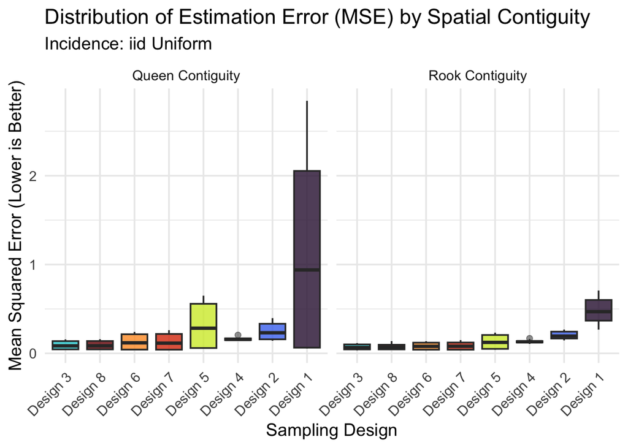

MLE: Distribution of MSE by design, faceted by spatial contiguity structure (iid Uniform incidence, tau = 1.0).

## 9.4 Coverage by Design

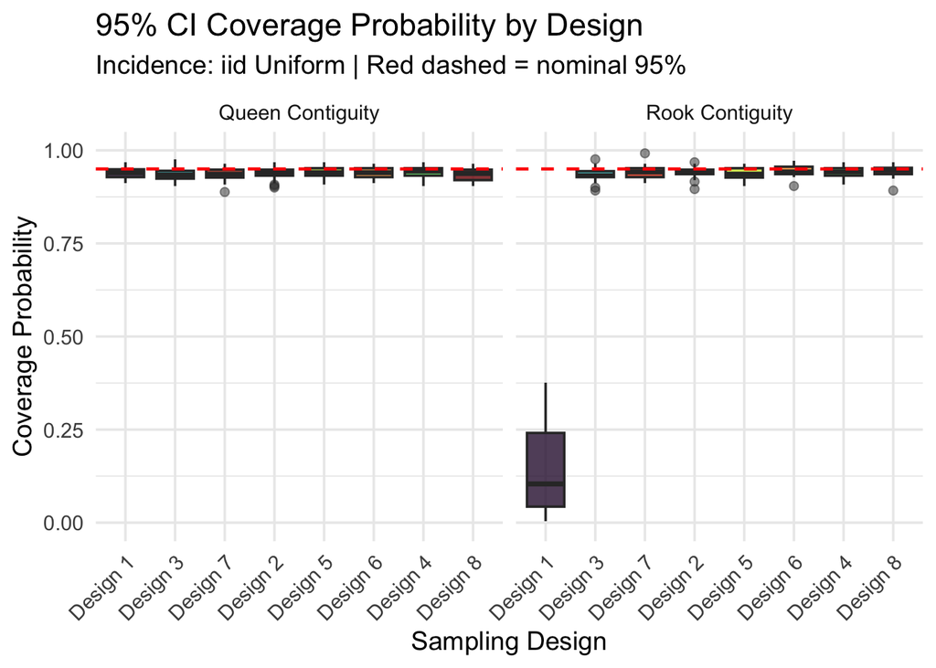

## 9.5 Bias-Variance Decomposition

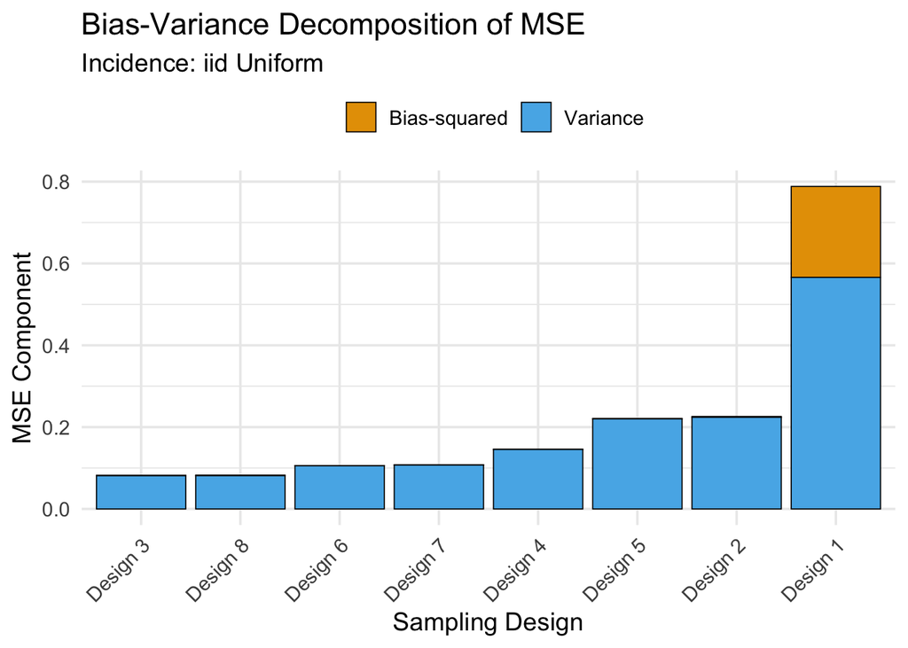

MLE: Bias-squared (dark) and variance (light) components of MSE per design for iid Uniform incidence (tau = 1.0, rook and queen pooled).

# 10 Results: Formal Statistical Comparisons

The descriptive summaries above rank designs by mean MSE, but do not establish whether observed differences are *statistically significant*. Here we apply non-parametric hypothesis tests to the paired MSE values across the 320 unique parameter blocks. Each block is a unique combination of simulation parameters (Incidence Mode × Neighbor Type × $\rho$ × $\gamma$ × Spillover Type); within each block all 8 designs are evaluated under identical conditions, creating a paired repeated-measures structure. **These tests pool rook and queen blocks at $\tau = 1.0$.** For the primary queen structure alone (160 blocks), the Friedman statistic is $\chi^2 = 711.29$ (df = 7, $p < 2 \times 10^{-16}$); queen, rook and pooled results for all 8 designs are in `results/eight_design_supplementary/eight_design_summary.txt`. Blocks within an incidence configuration share the same 10 incidence surfaces, so treating blocks as independent overstates the information about surface-to-surface variation.

Three complementary tests are used: (1) the **Friedman test** (omnibus — is there any significant difference among designs?), (2) **Nemenyi post-hoc** comparisons with family-wise error control (which specific pairs differ?), and (3) pairwise **Wilcoxon signed-rank tests** with Holm correction (sensitivity check). Significance level $\alpha = 0.05$ throughout.

## 10.1 Friedman Omnibus Test

Friedman omnibus test: are any design MSE ranks significantly different?

| Chi-squared | df | P-value | N Blocks | Decision |
| --- | --- | --- | --- | --- |
| 1573.47 | 7 | <2e-16 | 320 | Reject H0 |

The pooled Friedman test ($\chi^2 = 1573.47$, $p < 2.2 \times 10^{-16}$) decisively rejects the null hypothesis that all 8 designs perform equally. The table below shows each design’s **average MSE rank** across all blocks (rank 1 = best):

Average MSE rank per design across all 320 blocks (rook and queen pooled; 1 = best).

| Design | Average Rank |
| --- | --- |
| Design 3 | 2.191 |
| Design 8 | 2.328 |
| Design 6 | 3.138 |
| Design 7 | 3.175 |
| Design 4 | 5.181 |
| Design 5 | 5.759 |
| Design 2 | 6.866 |
| Design 1 | 7.362 |

## 10.2 Critical Difference Diagram

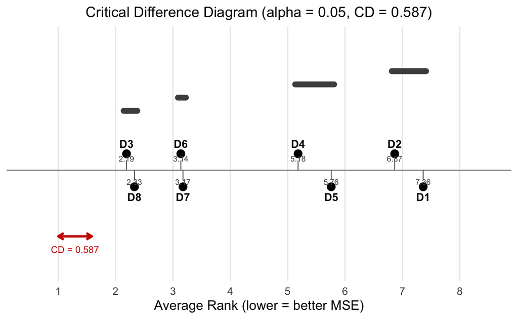

Critical Difference (CD) diagram from Nemenyi post-hoc analysis. Designs are placed on a number line by average MSE rank (lower = better). Thick bars connect designs that are NOT significantly different at alpha = 0.05. The red arrow shows the CD threshold.

**How to read this diagram:** Designs positioned closer together are more similar in performance. A thick bar connecting two designs means their difference is *not* statistically significant. The red arrow labelled “CD” shows the critical difference threshold — any two designs separated by more than this distance are significantly different.

The headline finding: **Saturation Quadrants and Incidence-Guided Saturation Quadrants form the top equivalence group** — statistically indistinguishable from each other (Nemenyi $p = 0.997$ pooled, $0.985$ queen) and significantly better than every other design in both the pooled and the queen-only analysis. Under rook alone they are not significantly separated from Balanced Quartiles or Balanced Halves (Nemenyi $p$ from 0.10 to 0.33). **Checkerboard has the worst pooled average rank, but it is not significantly worse than every alternative:** pooled, it does not differ significantly from High Incidence Focus (Nemenyi $p = 0.17$); under queen, Checkerboard, High Incidence Focus and 2x2 Blocking are not significantly different from one another (Nemenyi $p$ = 1.00, 0.62, 0.55). Under rook, Checkerboard ranks last in nearly every block (average rank 7.99 of 8) because $\tau$ is not identified there.

## 10.3 Pairwise Significance: MSE Distributions

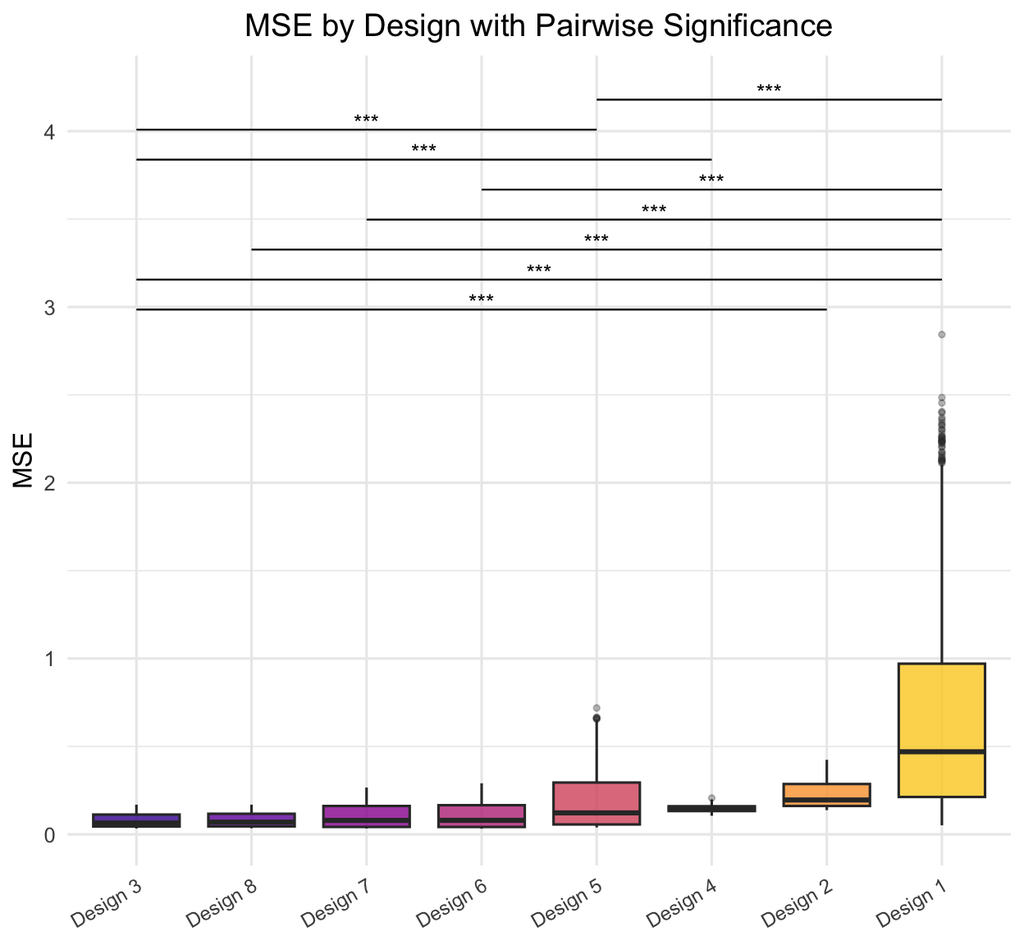

MSE distribution by design (tau = 1.0, rook and queen pooled; ordered by median MSE, best on left). Significance brackets show pairwise Wilcoxon signed-rank test results (Holm-adjusted). Stars: *** p < 0.001, ** p < 0.01, * p < 0.05.

The boxplot (rook and queen pooled) confirms the rank-based findings: Saturation Quadrants and Incidence-Guided Saturation Quadrants have the lowest and most compact MSE distributions, while Checkerboard has both the highest median and the widest spread. Its MSE comes from two sources: a large variance under queen with control-only spillover (bias near 0), where the Spill covariate is nearly collinear with $Z$, and, under rook, a bias of about $-\gamma$ because $\tau$ is not identified. Significance brackets annotate the most informative pairwise comparisons.

## 10.4 Pairwise P-value Heatmap

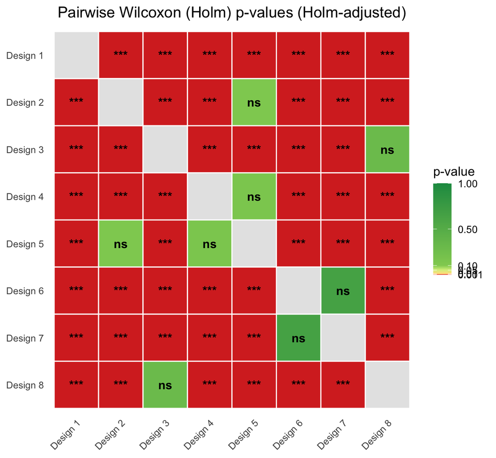

Pairwise Wilcoxon signed-rank p-values (Holm-adjusted; rook and queen pooled). Red = strongly significant (p < 0.001), orange = significant (p < 0.01 or < 0.05), grey/green = not significant.

Of the 28 pairwise comparisons, **24 are statistically significant** under Wilcoxon (Holm) and **24** under Nemenyi post-hoc. The 4 non-significant pair(s) are:

Design pairs with no statistically significant MSE difference.

| Design A | Design B | Wilcoxon p | Nemenyi p |
| --- | --- | --- | --- |
| Design 2 | Design 5 | 0.1241 | 0.0000 |
| Design 3 | Design 8 | 0.2976 | 0.9967 |
| Design 4 | Design 5 | 0.1527 | 0.0570 |
| Design 6 | Design 7 | 0.6513 | 1.0000 |

## 10.5 Robustness: Conditional Tests by Parameter

To confirm that the design rankings are not an artifact of any particular parameter setting, we repeat the Friedman test within strata defined by each simulation parameter individually.

Friedman test within each parameter stratum. 'Best Group' lists designs statistically indistinguishable from the best-ranked design.

| Parameter | Stratum | Chi-sq | P-value | N Blocks | Best Group |
| --- | --- | --- | --- | --- | --- |
| Rho | Rho = 0 | 394.65 | < 2.2e-16 | 80 | D3, D8, D6, D7 |
| Rho | Rho = 0.01 | 403.31 | < 2.2e-16 | 80 | D8, D3, D7, D6 |
| Rho | Rho = 0.2 | 398.61 | < 2.2e-16 | 80 | D3, D8, D7 |
| Rho | Rho = 0.5 | 380.75 | < 2.2e-16 | 80 | D3, D8, D6, D7 |
| Gamma | Gamma = 0.5 | 396.29 | < 2.2e-16 | 80 | D8, D3, D6, D7 |
| Gamma | Gamma = 0.6 | 389.30 | < 2.2e-16 | 80 | D3, D8, D7 |
| Gamma | Gamma = 0.7 | 390.98 | < 2.2e-16 | 80 | D3, D8, D6, D7 |
| Gamma | Gamma = 0.8 | 399.49 | < 2.2e-16 | 80 | D8, D3, D6, D7 |
| Spillover_Type | Spillover_Type = both | 889.37 | < 2.2e-16 | 160 | D6, D7, D3 |
| Spillover_Type | Spillover_Type = control_only | 1019.96 | < 2.2e-16 | 160 | D8, D3 |
| Neighbor_Type | Neighbor_Type = queen | 711.29 | < 2.2e-16 | 160 | D3, D8 |
| Neighbor_Type | Neighbor_Type = rook | 900.22 | < 2.2e-16 | 160 | D3, D8, D6, D7 |
| Incidence_Mode | Incidence_Mode = iid | 314.23 | < 2.2e-16 | 64 | D3, D8, D6, D7 |
| Incidence_Mode | Incidence_Mode = poisson | 633.48 | < 2.2e-16 | 128 | D3, D8 |
| Incidence_Mode | Incidence_Mode = spatial | 626.54 | < 2.2e-16 | 128 | D3, D8 |

The Friedman test is **significant in every stratum** ($p < 2.2 \times 10^{-16}$ in all cases). Saturation Quadrants appears in the top equivalence group in every stratum, and Incidence-Guided Saturation Quadrants in every stratum except bidirectional (“both”) spillover, where Balanced Quartiles ranks first and Balanced Halves and Saturation Quadrants are statistically tied with it. Except for the Neighbor_Type rows, each stratum pools rook and queen blocks.

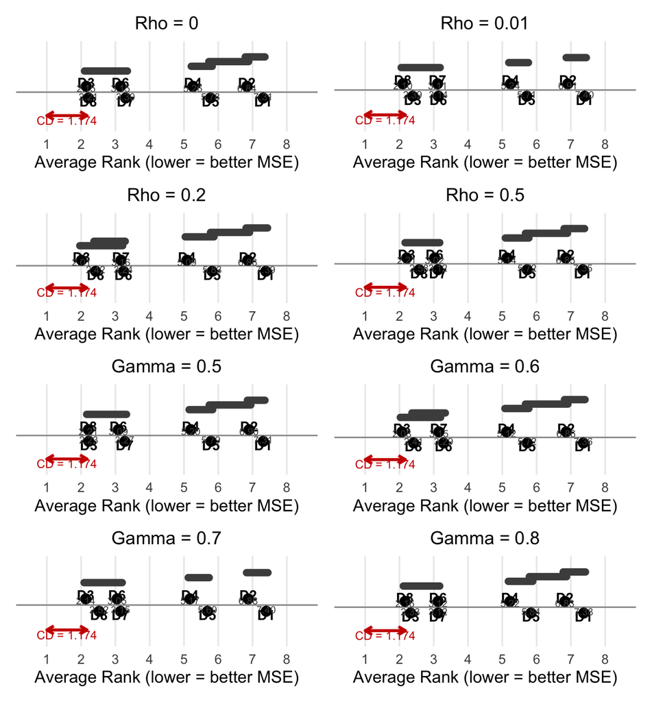

CD diagrams by outcome spatial autocorrelation (Rho, top) and spillover magnitude (Gamma, bottom). Rankings are consistent across levels.

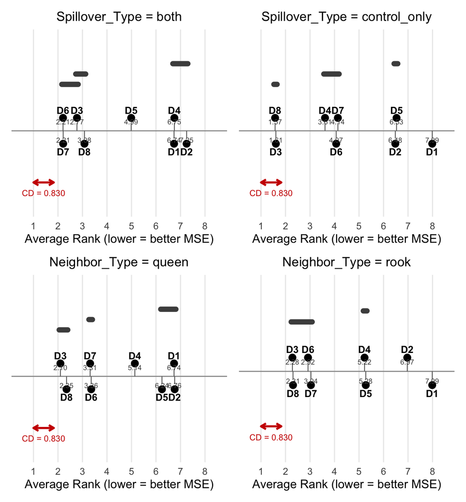

CD diagrams by spillover type (top) and neighbor contiguity type (bottom). The top of the ranking is similar across spillover types and contiguity definitions; the bottom differs (under rook, Checkerboard is last because tau is not identified).

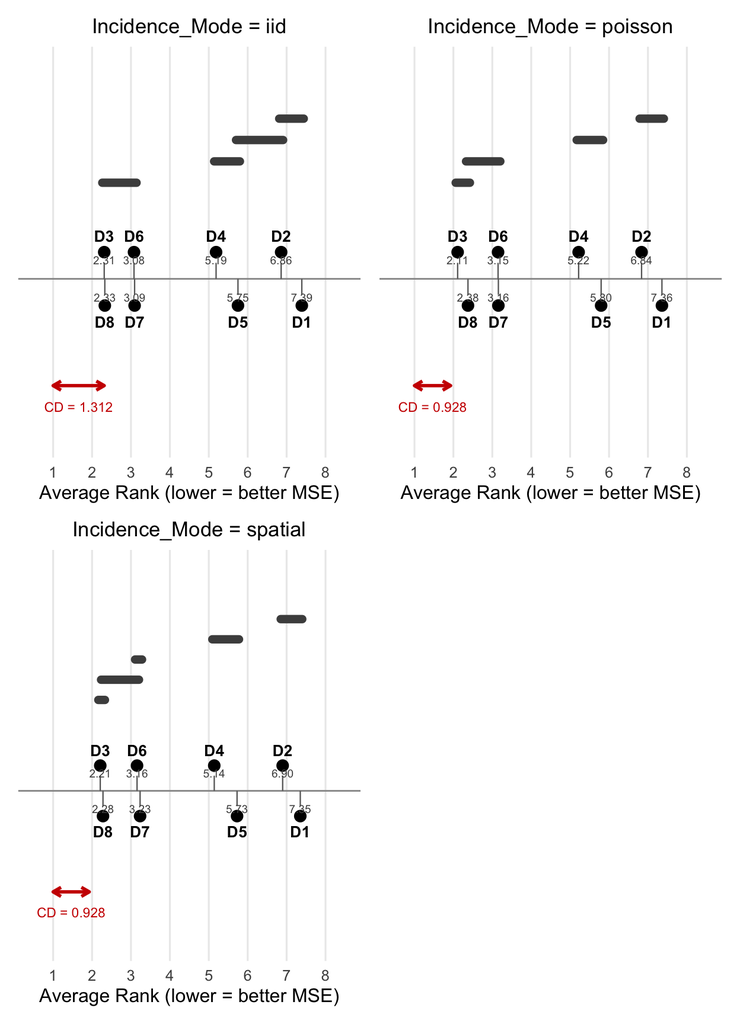

> For full methods background (Friedman test derivation, CD formula, Wilcoxon procedure with references) and complete pairwise p-value matrices, see the companion report: **Statistical Comparison of Treatment Assignment Designs** (`11_statistical_comparisons_report.pdf` in the results directory).

## 10.6 Summary of Statistical Findings

Taken together, the Friedman test, Nemenyi post-hoc comparisons, and pairwise Wilcoxon signed-rank tests (all pooling rook and queen at $\tau = 1.0$ unless stated) converge on a clear and consistent picture:

- **Design differences are real, not chance.** The pooled Friedman omnibus test ($\chi^2 = 1573.47$, $p < 2.2 \times 10^{-16}$) provides overwhelming evidence that the 8 designs do not perform equally. The average rank gap between best and worst is 5.17 points on an 8-point scale.
- **Saturation Quadrants and Incidence-Guided Saturation Quadrants are the recommended designs.** Saturation Quadrants (Design 3, avg rank 2.19) and Incidence-Guided Saturation Quadrants (Design 8, avg rank 2.33) form the top equivalence group — they are statistically indistinguishable from each other and, pooled and under queen, significantly better than every other design (under rook alone, not significantly separated from Balanced Quartiles or Balanced Halves). The data do not favor one of the two over the other.
- **Avoid Checkerboard.** With a pooled average rank of 7.36, Checkerboard is last. Under rook, $\tau$ is not identified (bias about $-\gamma$, coverage 0.15); under queen, its coverage is near nominal but its MSE is the largest of the 8 designs (1.087 vs 0.090 for Saturation Quadrants), and it is not significantly different from High Incidence Focus or 2x2 Blocking.
- **24 of 28 design pairs are significantly different** (pooled Nemenyi post-hoc; 24 under Wilcoxon/Holm). The non-significant pairs include the two near-identical pairs (Saturation Quadrants vs Incidence-Guided Saturation Quadrants; Balanced Quartiles vs Balanced Halves) and pairs among the lower-ranked designs (see the table above).
- **Rankings are robust.** The Friedman test is significant in every parameter stratum tested ($p < 2.2 \times 10^{-16}$ across all levels of $\rho$, $\gamma$, spillover type, neighbor type, and incidence mode). Saturation Quadrants is in the top equivalence group in every stratum, and Incidence-Guided Saturation Quadrants in every stratum except bidirectional spillover, so the recommendation generalises beyond any single scenario. Per-stratum tests share incidence surfaces and noise draws, so they are not independent confirmations of one another.

# 11 Results: Design Rankings by Incidence Mode (Q1)

## 11.1 Cross-Config MSE Rankings

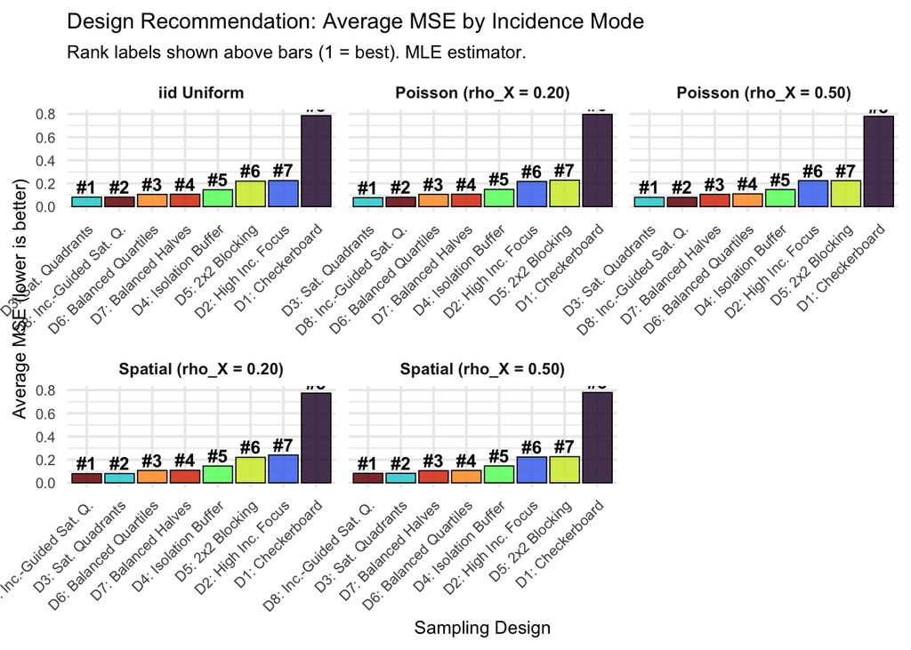

Average MSE per design for each incidence configuration (tau = 1.0, rook and queen pooled). Bars sorted left-to-right (lowest = best). Rank labels above bars.